# ÉTUDE GÉNÉRALISÉE DE LA SOUS-NUTRITION DANS LE MONDE

## *III.3. Des pays dans l'urgence alimentaire*

Nous avons observé la situation de l'Inde et de la Chine, mais observons maintenant de façons générale les taux de sous-nutrition donnés selon les clusters.

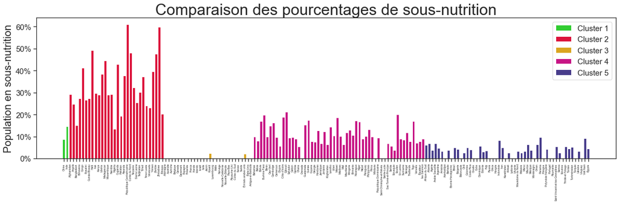

```python
figure = plt.figure(figsize=(20, 5))
axes = figure.add_subplot(111)

world_per("und_percentage", axes)

axes.set_title("Comparaison des pourcentages de sous-nutrition", fontsize=30)
axes.set_ylabel("Population en sous-nutrition", fontsize=20)
plt.yticks(fontsize=15)
plt.show()
```

Le Cluster 2 se distingue des quatre autres groupes de pays avec une marge importante. Comme mentionné en mission 1, nous observons des pourcentages de sous-nutrition locale allant jusqu'à 60%. Analysons donc les besoins des pays du cluster 2 en les mentionnant.

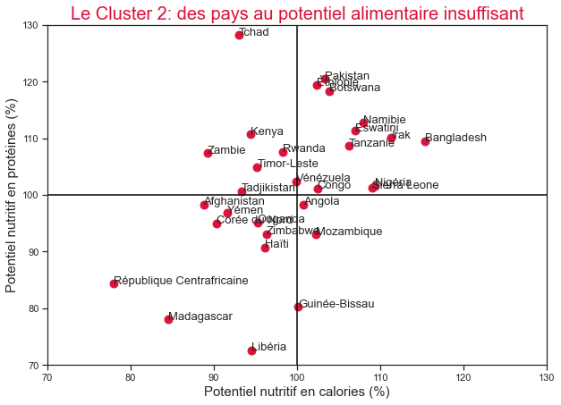

```python
fig, ax = plt.subplots(figsize=(10, 7))

plt.axhline(100, color="black")
plt.axvline(100, color="black")

w2.plot.scatter(ax=ax, x="potentiel_calorie", y="potentiel_proteine",
                s=80, color="crimson", fig=fig)


for (i, txt) in enumerate(w2.index):

    ax.annotate(txt, (w2["potentiel_calorie"][i], w2["potentiel_proteine"][i]),
                size=13, xytext=(0,0), ha="left", textcoords="offset points")

plt.xlim(70, 130) ; plt.ylim(70, 130)
plt.xlabel("Potentiel nutritif en calories (%)", fontsize=15)
plt.ylabel("Potentiel nutritif en protéines (%)", fontsize=15)
plt.title("Le Cluster 2: des pays au potentiel alimentaire insuffisant", fontsize=20, color="crimson")
plt.show()
```

Sont donc affichés ici les pays dans l'urgence alimentaire la plus rouge. Nous trouvons donc avant tout des pays d'Afrique et d'Asie Centrale. Distinguons la République Centrafricaine, Madagascar et le Libéria où le potentiel alimentaire est globalement on-ne-peut-plus faible. Les potentiels alimentaires au-dessus de 100% pour les deux unités d'énergie pour le cluster 2 restent tout de même très fragile, n'excédant pas tous deux 120%, ce qui est relativement faible comparé à un pays auto-suffisant comme ceux des clusters 3 et 5. Nous pourrons donc considérer l'ensemble des pays du cluster 2 comme des pays ayant recours à une aide alimentaire extérieure, humanitaire ou plan d'états international. Nous avons relevé un potentiel alimentaire fragile pour les pays du cluster 4, c'est pourquoi nous nous penchons également sur les besoins de ces pays sur le graphique suivant.

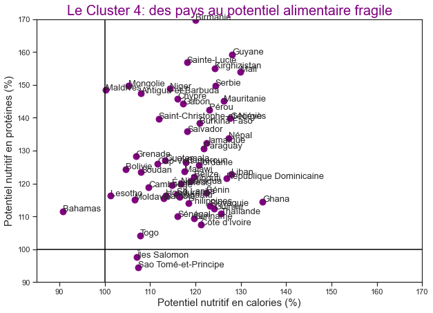

```python
fig, ax = plt.subplots(figsize=(10, 7))

plt.axhline(100, color="black")
plt.axvline(100, color="black")

w4.plot.scatter(ax=ax, x="potentiel_calorie", y="potentiel_proteine",
                s=80, color="purple", fig=fig)


for (i, txt) in enumerate(w4.index):

    ax.annotate(txt, (w4["potentiel_calorie"][i], w4["potentiel_proteine"][i]),
                size=13, xytext=(0,0), ha="left", textcoords="offset points")

plt.xlim(85, 170)
plt.ylim(90, 170)
plt.xlabel("Potentiel nutritif en calories (%)", fontsize=15)
plt.ylabel("Potentiel nutritif en protéines (%)", fontsize=15)
plt.title("Le Cluster 4: des pays au potentiel alimentaire fragile", fontsize=20, color="purple")
plt.show()
```

Nous pouvons alors porter une priorité équivalente aux pays du cluster 2, aux Bahamas, aux Îles Salomon et à l'Île de Sao-Tomé pour ce qui est de l'urgence alimentaire. Ces pays souffrent d'une insuffisance pour une unité d'énergie et d'une fragilité pour la deuxième. Les pays restants seront à prendre en compte également, dans une mesure d'urgence moindre, mais également importante.

# Mission 4: Axes de lutte contre la faim dans le monde

*Dans cette dernière mission du projet, nous ne considérerons plus à présent que le monde dispose largement de quoi nourrir le monde entier, comme en témoigne les résultats de la partie III.2. de la mission 1. Nous ne tiendrons plus compte non plus de la différenciation entre les deux unités d'énergie, calories et protéines. Nous nous baserons sur l'état actuel de la sous-nutrition dans le monde, sur les différents types d'utilisation des productions alimentaires, et en proposerons quelques idées de réaménagement en vue de "libérer" des disponibilités alimentaires supplémentaires que l'on pourrait spécifiquement destiner aux êtres humains souffrants de sous-nutrition. Nous considérerons cependant le clustering effectué en mission 3 pour globaliser certaines zones du monde.*

# I. Utilisation de la disponibilité alimentaire

## *I.1. Remaniement du DataFrame et présentation de nouvelles variables*

- *nourished* Le nombre d'êtres humains en autosuffisance alimentaire (population mondiale optée de la population en sous-nutrition).
- *food* La quantité en milliers de tonnes de la disponibilité alimentaire destinée à la nourriture pour l'homme.
- *feed* La quantitée en milliers de tonnes de la disponibilité alimentaire destinée aux animaux.
- *waste* La quantité en milliers de tonnes de la disponibilité alimentaire faisant l'objet de pertes.
- *other_uses* La quantité en milliers de tonnes de la disponibilité alimentaire restant, destinée à d'autres types de productions.
- *food_per* Le pourcentage de la disponibilité alimentaire destinée à la nourriture au sein d'un pays donné.
- *feed_per* Le pourcentage de la disponibilité alimentaire destinée aux animaux.
- *waste_per* Le pourcentage de la disponibilité alimentaire faisant l'objet de pertes.
- *other_uses_per* Le pourcentage de la disponibilité alimentaire restant, destinée à d'autres types de productions (cosmétie, carburant...).
- *exportation*: Qui représentera le pourcentage de la disponibilité alimentaire exportée vers des pays extérieurs.

```python
gf = pd.read_csv("data/projet_R/ou.csv").set_index("country")
world = pd.read_csv("data/projet_R/world.csv").set_index("country")

world = world[["cluster", "population", "undernourished", "und_percentage", "potentiel", "domestic_supply"]]

world = world.join(gf) # Introduction des pourcentages d'utilisations.
world["nourished"] = world["population"]-world["undernourished"] # Taux d'êtres humains rassasiés, inverse de undernourished.

world["food"] = world["domestic_supply"]*world["food_per"]/100 # Introduction des quantités d'utilisations.
world["feed"] = world["domestic_supply"]*world["feed_per"]/100
world["waste"] = world["domestic_supply"]*world["waste_per"]/100
world["other_uses"] = world["domestic_supply"]*world["other_uses_per"]/100

exp = pd.read_csv("data/projet_R/W/alim.csv").set_index("country") # Introduction du pourcentage d'exportations.
exp = exp.drop(columns = "domestic_supply") ; world = world.join(exp)

world.to_csv("data/projet_R/world_food_waste.csv")

world[["population", "nourished", "domestic_supply", "food", "feed", "waste", "other_uses", "exportation"]]
```

| country | population | nourished | domestic_supply | food | feed | waste | other_uses | exportation |
| --- | --- | --- | --- | --- | --- | --- | --- | --- |
| Afghanistan | 36296110.0 | 25696110.0 | 15139.0 | 12968.0 | 456.0 | 1146.0 | 569.0 | 3.622664 |
| Afrique du Sud | 57009760.0 | 53509760.0 | 66840.0 | 31726.0 | 9371.0 | 3108.0 | 22635.0 | 14.572443 |
| Albanie | 2884170.0 | 2684170.0 | 4879.0 | 3631.0 | 697.0 | 321.0 | 230.0 | 3.007519 |
| Algérie | 41389190.0 | 39789190.0 | 45365.0 | 33056.0 | 4884.0 | 3683.0 | 3742.0 | 1.585743 |
| Allemagne | 82658410.0 | 82658410.0 | 174960.0 | 77988.0 | 30904.0 | 5756.0 | 60312.0 | 25.015211 |
| ... | ... | ... | ... | ... | ... | ... | ... | ... |
| Émirats arabes unis | 9487200.0 | 9287200.0 | 11795.0 | 5958.0 | 1479.0 | 525.0 | 3833.0 | 29.121726 |
| Équateur | 16785360.0 | 15485360.0 | 23810.0 | 9465.0 | 1017.0 | 860.0 | 12468.0 | 26.674462 |
| États-Unis | 325084760.0 | 325084760.0 | 849821.0 | 322036.0 | 151389.0 | 36551.0 | 339845.0 | 19.554621 |
| Éthiopie | 106399920.0 | 84799920.0 | 55860.0 | 38502.0 | 4710.0 | 2915.0 | 9733.0 | 5.880539 |
| Îles Salomon | 636040.0 | 579040.0 | 989.0 | 419.0 | 15.0 | 54.0 | 501.0 | 13.509061 |

166 rows × 8 columns

## *I.2. Ajustement de constantes et définitions de fonction*

Voyons si la disponibilité alimentaire en nourriture destinée à l'homme est proportionnelle à l'autosuffisance alimentaire. Nous retirerons les quelques pays à la population supérieure à 500 millions d'habitants pour une meilleure visibilité des résultats.

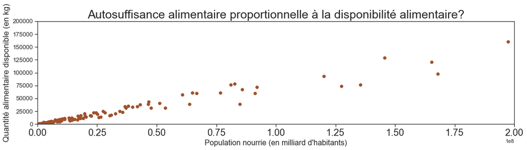

```python
dim(18, 4)

plt.plot(world["nourished"], world["food"],
         "o", color="sienna")

plt.title("Autosuffisance alimentaire proportionnelle à la disponibilité alimentaire?", fontsize=25)
plt.xlabel("Population nourrie (en milliard d'habitants)", fontsize=16)
plt.xticks(fontsize=20)
plt.ylabel("Quantité alimentaire disponible (en kg)", fontsize=17)
plt.yticks(fontsize=13)
plt.xlim(0, 2*10**8)
plt.ylim(0, 2*10**5)
plt.show()
```

On constate qu'une droite croissante se dégage de ce nuage de points par régression linéaire. On en déduit une proportionnalité sensible entre la quantité de nourriture disponible et le nombre d'êtres humains nourris. On peut donc estimer que la quantité de nourriture totale peut nourrir environ 89,54% du monde entier. Nous tirerons de cette proportion des estimations du nombre d'êtres humains supplémentaires pouvant être nourris en libérant certaines quantités de nourritures.

```python
FQ=world["food"].sum() # Disponibilité alimentaire mondiale destinée à l'homme en milliers de tonnes de nourritures.
PN=round(POPULATION-SSN,0) # Population totale en autosuffisance alimentaire.
PRCN=round(100*PN/POPULATION,2) # Pourcentage de la population totale en autosuffisance alimentaire.

print("Le monde dispose d'une quantité alimentaire totale de {} kg,".format(FQ),
      " ce qui nourrit environ {}% de la population totale,".format(PRCN)) ; print("soit {} d'êtres humains.".format(PN))
```

[output not shown]

En vue des analyses répétées que nous exécuterons, nous nous servirons de la fonction **barre_nutritive** (suivez bien, cette fonction est particulière!) qui prendra notamment en argument une zone (le monde entier, un cluster ou un pays), le pourcentage de la population de cette zone en autosuffisance alimentaire A, ainsi qu'un pourcentage de cette même population B susceptible d'être nourrie par une quelconque libération alimentaire extérieure ut (pertes alimentaires ou nourritures pour animaux par exemple). Cette fonction nous renverra alors un diagramme horizontal unique, sommant la population nourrie et la population susceptible d'être nourrie par la libération alimentaire citée, et nous donnant donc une estimation du pourcentage de la population de cette zone pouvant être nourrie si l'on libérait cette dite disponibilité alimentaire. Nous donnerons par ailleurs une couleur spécifique en argument pour pouvoir distinguer les barres obtenues. L'exemple de la partie II.1. de la mission 4 qui va suivre vous permettra de comprendre l'utilisation de cette fonction si mon explication n'est pas claire.

```python
def barre_nutritive(A, B, couleur, zone, ut, s):
    dim(18, 2)

    plt.barh(" ", A, color=couleur, label="Population du {} en autosuffisance alimentaire (en %)".format(zone))

    plt.barh(" ", B, left=A, color="darkkhaki",
             label="Population du {} pouvant être nourrie avec la disp. alimentaire libérée par {} (en %)".format(zone, ut))

    plt.xticks(range(0, s, 5), fontsize=20)
    plt.legend(loc="upper left", fontsize=15)
```

Nous nous pencherons dans cette dernière mission sur la distribution des ressources alimentaires.

## *I.3. Taux d'utilisation de la disponibilité alimentaire*

Voyons dans un premier temps comment est globalement utilisée cette disponibilité alimentaire sur un diagramme circulaire.

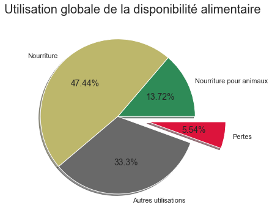

```python
s1, s2, s3, s4 = world["food"].sum(), world["feed"].sum(), world["other_uses"].sum(), world["waste"].sum()

dim(6, 6)

plt.pie([s2, s1, s3, s4],
        labels = ["Nourriture pour animaux", "Nourriture",
                  "Autres utilisations", "Pertes"],
        colors=["seagreen", "darkkhaki", "dimgray", "crimson"],
        autopct=lambda x: str(round(x, 2))+"%",
        shadow=True, explode = [0, 0, 0, 0.4])

plt.title("Utilisation globale de la disponibilité alimentaire",fontsize = 20)
plt.ylabel("")
plt.axis("equal")
plt.show()
```

**Nous relevons sinon un taux de pertes assez important de 5,54%.**

# II. Pertes alimentaires

## *II.1. Potentiel alimentaire pouvant être libéré*

Imaginons maintenant que nous distribuions les pertes alimentaires de façon équitablement répartie à l'ensemble de la population mondiale en sous-nutrition. Si l'on estime du graphique précédent que **47,44% de la disponibilité alimentaire totale peut nourrir 89,54% de la population mondiale**, il suffit d'un simple calcul mathématique pour voir ce que les **5,54% de pertes auraient pu rassasier**.

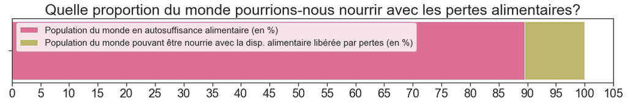

```
On nourrirait donc 100.0% du monde si les pertes alimentaires étaient consommées équitablement par la
population en sous-nutrition
```

```python
PT=PRCN*5.54/47.44 # Pourcentage de la population mondiale pouvant être nourrie par l'ensemble des pertes alimentaires.
PT=round(PT, 2)

barre_nutritive(PRCN, PT, "palevioletred", "monde", "pertes", 106)

plt.title("Quelle proportion du monde pourrions-nous nourrir avec les pertes alimentaires?", fontsize=25)
plt.show()

print("On nourrirait donc {}% du monde si les pertes alimentaires étaient consommées équitablement par la".format(PRCN+PT))
print("population en sous-nutrition")
```

Il nous faut admettre que ce score rond de 100%, fruit de notre estimation, est un hasard. En considérant donc la qualité des paramètres de notre estimation, on peut donc admettre que les pertes libererait de justesse le monde de la faim! Nous allons maintenant repérer les zones géographiques où l'on peut relever des pertes importantes.

## *II.2. Ciblage géographique*

Repérons donc d'abord les pays dont le pourcentage des pertes alimentaires est le plus élevé selon leurs clusters définis à la mission 3. Ce premier graphique ne présentera donc pas de résultats pour ce qui est des pertes de quantités alimentaires.

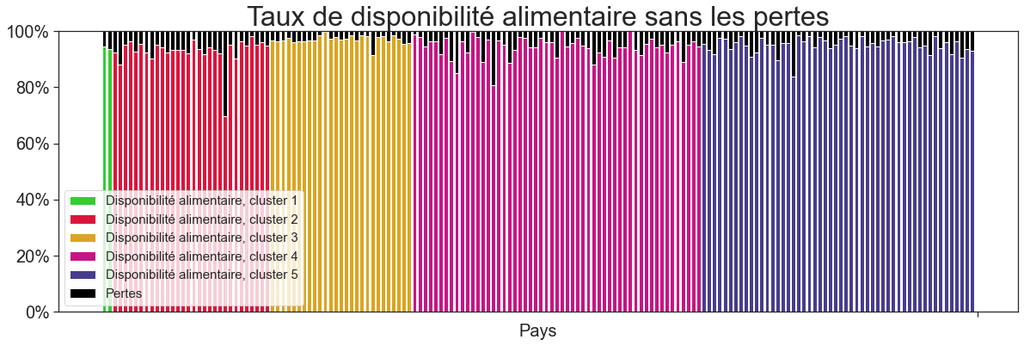

```python
w1, w2, w3, w4, w5 = world_cluster(1), world_cluster(2), world_cluster(3), world_cluster(4), world_cluster(5)

fig, axes = plt.subplots(figsize=(20, 6))

c=0
for data in [w1, w2, w3, w4, w5]:
    axes.bar(data.index, data["food_per"]+data["feed_per"]+data["other_uses_per"],
             label="Disponibilité alimentaire, cluster %s" %(c+1),
             color=palette[c])
    c+=1

axes.bar(world.index, world["waste_per"],
         bottom=world["food_per"]+world["feed_per"]+world["other_uses_per"],
         label="Pertes", color="black")

plt.title("Taux de disponibilité alimentaire sans les pertes", fontsize=32)
axes.set_yticklabels(["{}%".format(int(x)) for x in axes.get_yticks()], fontsize=15)
plt.xticks("")
plt.yticks(fontsize=20)
plt.xlabel("Pays", fontsize=20)
plt.legend(fontsize=15)
plt.show()
```

Remarquons que les pertes sont plus importantes dans les pays des clusters 2 et 4. En revanche, ces deux derniers clusters disposantes des quantités alimentaires les plus faibles, on peut supposer que leurs pertes ne sont pas les plus élevées en terme de quantités. C'est donc ce que nous allons maintenant observer sur le camembert suivant.

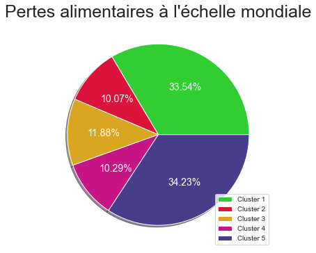

```python
dim(6, 6)

world_pie("waste")
plt.title("Pertes alimentaires à l'échelle mondiale", fontsize=(25))
plt.show()
```

Les pertes alimentaires semblent équivalentes entre les pays pauvres et les pays riches en regardant les résultats pour les clusters 2, 3 et 4. En clair, la quantité alimentaire des pertes ne semble pas être corrélée au PIB du pays. La Chine et l'Inde sont à l'origine d'environ 1/3 des pertes alimentaires alors qu'ils présentent environ 42,89% de la sous-nutrition mondiale. Nous observerons donc ce que ces pertes pourraient combler au sein de ce cluster. L'observation de ce graphique nous poussera également à nous concentrer sur le cluster 5. Ce graphique montre que plus du tiers de l'ensemble des pertes alimentaires proviennent du cluster 5, alors que ce groupe de pays représentent 22,64% de la population mondiale.

## *II.3. Des pertes à l'origine de la sous-nutrition locale dans certains pays*

Nous allons maintenant regarder la proportion de la population que l'on pourrait nourrir dans les pays des clusters 1 et 5 si les pertes étaient réutilisées pour de la nourriture et équitablement distribuées aux habitants en sous-nutrition.

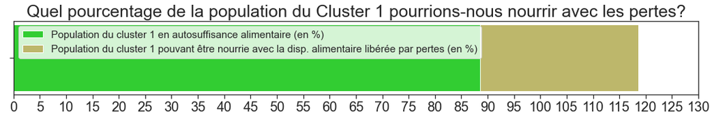

```
________________________________________________________________________________________________________________________
```

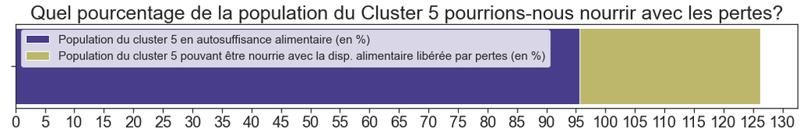

```python
# Cluster 1:

up1=100*w1["nourished"].sum()/w1["population"].sum()
np1=33.54*PRCN/100

barre_nutritive(up1, np1, "limegreen", "cluster 1", "pertes", 131)

plt.title("Quel pourcentage de la population du Cluster 1 pourrions-nous nourrir avec les pertes?", fontsize=25)
plt.show()

print("_"*120)

# Cluster 5:

up5=100*w5["nourished"].sum()/w5["population"].sum()
np5=34.23*PRCN/100

barre_nutritive(up5, np5, "darkslateblue", "cluster 5", "pertes", 131)

plt.title("Quel pourcentage de la population du Cluster 5 pourrions-nous nourrir avec les pertes?", fontsize=25)
plt.show()
```

En dépit de sa population exhorbitante, on peut considérer les résultats comme fragiles pour le cluster 1. En revanche, les pertes locales pourraient combler l'Inde et la Chine de la famine si correctement distribuées. Ce mouvement paraissant difficilement réalisable à bien pour ces deux pays, on peut admettre que la gestion des pertes alimentaires contribueraient à venir à bout de la famine mais ne suffirait pas. C'est pourquoi nous maintenons notre conclusion à la mission 3, stipulant qu'une aide extérieure serait nécessaire pour le Cluster 1.

Nous avons vu que les pays du Cluster 5 disposaient tous d'un potentiel alimentaire autosuffisant (cf. mission 3), et nous avons supposé que la sous-nutrition (assez faible mais présente) était liée aux conditions politiques de ces pays pour ce qui est de la gestion alimentaire. Ces résultats nous confirment cette supposition. Sans les pertes, le cluster 5 serait nourrit à plus de 120%. Ce sera donc bien les politiques de gestion alimentaire qui seront à revoir au sein de ces pays pour y venir à bout de la sous-nutrition.